# Non-linear and local methods

Joshua Loftus

2/12/2021

## 2d non-linear classification data

```r
# sample size
n <- 800
# function with zero set that
# defines the perfect (Bayes) decision boundary
true_boundary_function <- function(x1, x2) {
  # experiment with changing this
  abs(x1-.5) - abs(2*x2+.5) + .3
}
train <- data.frame(
  # change the distribution
  # or scale as needed
  x1 = 1.5*(1 - 2*runif(n)),
  x2 = 1.5*(1 - 2*runif(n))
) %>%
  mutate(
    # labels if classes were perfectly separated
    separable = true_boundary_function(x1,x2) > 0,
    # labels if classes are "noisy"
    y = factor(rbinom(n, 1, 9/10 - (8/10) * as.numeric(separable)))
  )
```

### Plot the data

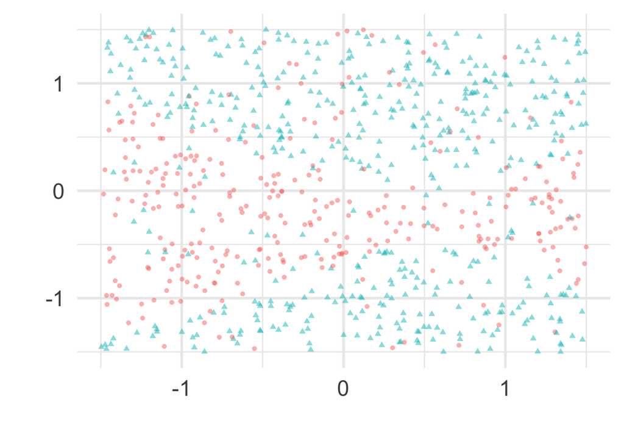

```r
train_plot <-
  ggplot(train, aes(x1, x2)) +
  geom_point(aes(shape = y, color = y),
             alpha = .5, show.legend = FALSE) +
  xlab("") + ylab("")

train_plot
```

### Plot the Bayes decision boundary

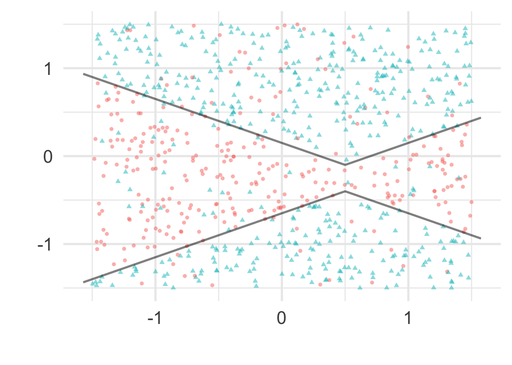

```r
decision_surface <-
  data_grid(train,
          x1 = seq_range(x1, 300, expand = .05),
          x2 = seq_range(x2, 300, expand = .05)) %>%
  mutate(z = true_boundary_function(x1, x2))

boundary_plot <-
  train_plot +
  geom_contour(
    data = decision_surface,
    aes(x1, x2, z=z),
    bins = 2,
    size = 1,
    color = "black",
    alpha = .5)

boundary_plot
```

### How well does linear classification do?

Also try changing the formula to fit a logistic regression model with non-linear transformations of the predictors

```r
# Fit model
logit_model <-
  glm(y ~ x1 + x2, family = "binomial", data = train)
# try formula + poly(x1,2) * poly(x2,2)

# Generate decision boundary
logit_surface <- logit_model %>%
   augment(type.predict = "response",
              newdata = decision_surface)
```

Plot decision boundary of logistic model

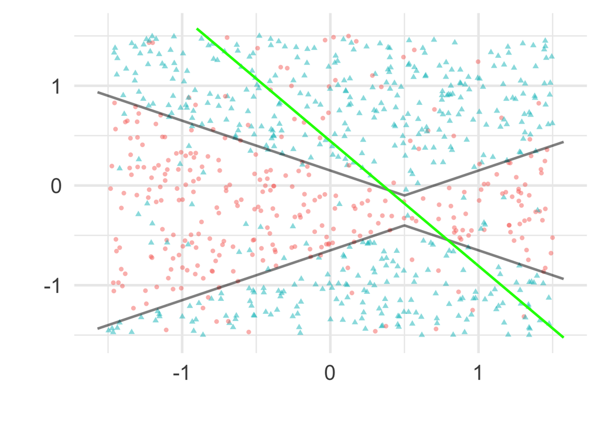

```r
boundary_plot +
  geom_contour(
    data = logit_surface,
    aes(x1, x2, z = .fitted),
    size = 1,
    color = "green",
    bins = 2)
```

```r
summary(logit_model)
```

```
##
## Call:
## glm(formula = y ~ x1 + x2, family = "binomial", data = train)
##
## Deviance Residuals:
##     Min       1Q   Median       3Q      Max
## -1.8431  -1.2220   0.7456   0.9897   1.5329
##
## Coefficients:
##             Estimate Std. Error z value Pr(>|z|)
## (Intercept)  0.48995    0.07538   6.500 8.03e-11 ***
## x1           0.48734    0.08941   5.451 5.02e-08 ***
## x2           0.38927    0.08625   4.513 6.39e-06 ***
## ---
## Signif. codes:  0 '***' 0.001 '**' 0.01 '*' 0.05 '.' 0.1 ' ' 1
##
## (Dispersion parameter for binomial family taken to be 1)
##
##     Null deviance: 1065.4  on 799  degrees of freedom
## Residual deviance: 1015.0  on 797  degrees of freedom
## AIC: 1021
##
## Number of Fisher Scoring iterations: 4
```

## 1-d smooth regression example

Generate a one-dimensional example with a non-linear relationship

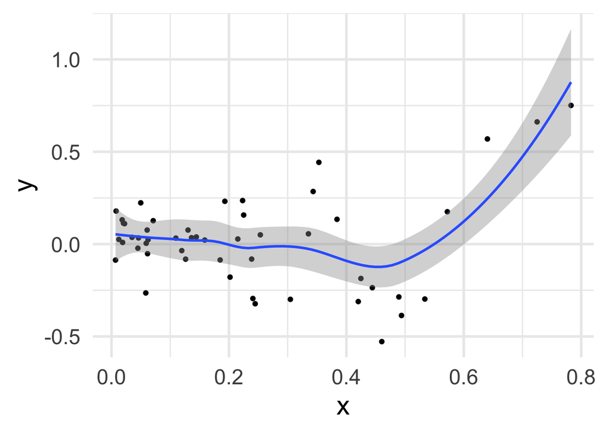

```r
# change this function
f <- function(x) x * sin(1/x^2)
n <- 50
train1d <-
  data.frame(
    x = rbeta(n, 1, 3)
    ) %>%
  # change the noise level sd
  mutate(y = f(x) + rnorm(n, sd = .1))

# plot data and loess curve
ggplot(train1d, aes(x, y)) +
  geom_point() +
  geom_smooth()
```

Linear regression with a polynomial transform of x

## Local methods

### Local averages/regression for 1d example

Write functions to compute:

- Average of k-nearest neighbors
- Local regression:
1. Gather the fraction s = k/n of training points whose xi are closest to x0.
2. Assign a weight Ki0 = K(xi,x0) to each point in this neighborhood, so that the point furthest from x0 has weight zero, and the closest has the highest weight. All but these k nearest neighbors get weight zero.
3. Fit a weighted least squares regression of the yi on the xi using the aforementioned weights
4. Use the weighted least squares model to predict for x0

Generate predictions from these methods and plot them

### Classify 2d example with k-nearest neighbors

Write a function to implement k-NN classification

You may use matrix operations but not any more sophisticated built-in R functions (or libraries)

Hint: https://en.wikipedia.org/wiki/Euclidean_distance_matrix#Relation_to_Gram_matrix

Plot the data and decision boundary for your k-NN classifier